# using_models_1

Analysis of Environmental Data 602

Emma Zimmerman Greenlee

2021-11-07

# Introduction

```r
require(here)
catrate = read.csv(here("data", "catrate.csv"))
head(catrate)
```

```
##   pond success years  cat.rate
## 1    2       5     7 0.2857143
## 2    3       5     7 0.2857143
## 3    4       6     7 0.1428571
## 4    5       4     7 0.4285714
## 5    6       0     7 1.0000000
## 6    7       1     4 0.7500000
```

```r
summary(catrate)
```

```
##       pond       success          years          cat.rate
##  Min.   : 2   Min.   :0.000   Min.   :1.000   Min.   :0.1429
##  1st Qu.: 5   1st Qu.:1.000   1st Qu.:3.000   1st Qu.:0.2857
##  Median : 8   Median :2.000   Median :4.000   Median :0.4286
##  Mean   : 8   Mean   :2.538   Mean   :4.692   Mean   :0.5394
##  3rd Qu.:11   3rd Qu.:5.000   3rd Qu.:7.000   3rd Qu.:0.7500
##  Max.   :14   Max.   :6.000   Max.   :7.000   Max.   :1.0000
```

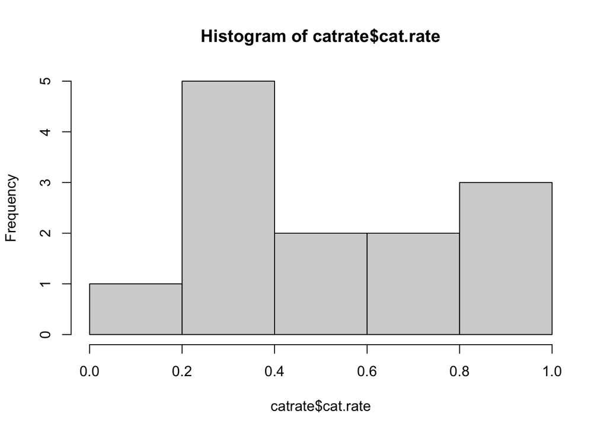

```r
hist(catrate$cat.rate)
```

```r
shapiro.test(catrate$cat.rate)
```

```
##
##  Shapiro-Wilk normality test
##
## data:  catrate$cat.rate
## W = 0.86202, p-value = 0.04097
```

```r
t.test(catrate$cat.rate, mu = 2/7)
```

```
##
##  One Sample t-test
##
## data:  catrate$cat.rate
## t = 2.9595, df = 12, p-value = 0.01193
## alternative hypothesis: true mean is not equal to 0.2857143
## 95 percent confidence interval:
##  0.3526250 0.7261295
## sample estimates:
## mean of x
## 0.5393773
```

```r
t.test(catrate$cat.rate, mu = 2/7, alternative = "greater")
```

```
##
##  One Sample t-test
##
## data:  catrate$cat.rate
## t = 2.9595, df = 12, p-value = 0.005966
## alternative hypothesis: true mean is greater than 0.2857143
## 95 percent confidence interval:
##  0.3866123       Inf
## sample estimates:
## mean of x
## 0.5393773
```

```r
t.test(catrate$cat.rate, mu = 2/7, alternative = "less")
```

```
##
##  One Sample t-test
##
## data:  catrate$cat.rate
## t = 2.9595, df = 12, p-value = 0.994
## alternative hypothesis: true mean is less than 0.2857143
## 95 percent confidence interval:
##       -Inf 0.6921422
## sample estimates:
## mean of x
## 0.5393773
```

```r
wilcox.test(catrate$cat.rate, mu = 2 / 7)
```

```
##
##  Wilcoxon signed rank test with continuity correction
##
## data:  catrate$cat.rate
## V = 85, p-value = 0.006275
## alternative hypothesis: true location is not equal to 0.2857143
```

```r
require(palmerpenguins)
penguin_dat = droplevels(subset(penguins, species != "Gentoo"))
summary(penguin_dat)
```

```
##       species          island    bill_length_mm  bill_depth_mm
##  Adelie   :152   Biscoe   : 44   Min.   :32.10   Min.   :15.50
##  Chinstrap: 68   Dream    :124   1st Qu.:37.75   1st Qu.:17.50
##                  Torgersen: 52   Median :40.60   Median :18.40
##                                  Mean   :41.91   Mean   :18.37
##                                  3rd Qu.:45.95   3rd Qu.:19.10
##                                  Max.   :58.00   Max.   :21.50
##                                  NA's   :1       NA's   :1
##  flipper_length_mm  body_mass_g       sex           year
##  Min.   :172.0     Min.   :2700   female:107   Min.   :2007
##  1st Qu.:187.0     1st Qu.:3400   male  :107   1st Qu.:2007
##  Median :191.0     Median :3700   NA's  :  6   Median :2008
##  Mean   :191.8     Mean   :3711                Mean   :2008
##  3rd Qu.:196.0     3rd Qu.:3988                3rd Qu.:2009
##  Max.   :212.0     Max.   :4800                Max.   :2009
##  NA's   :1         NA's   :1
```

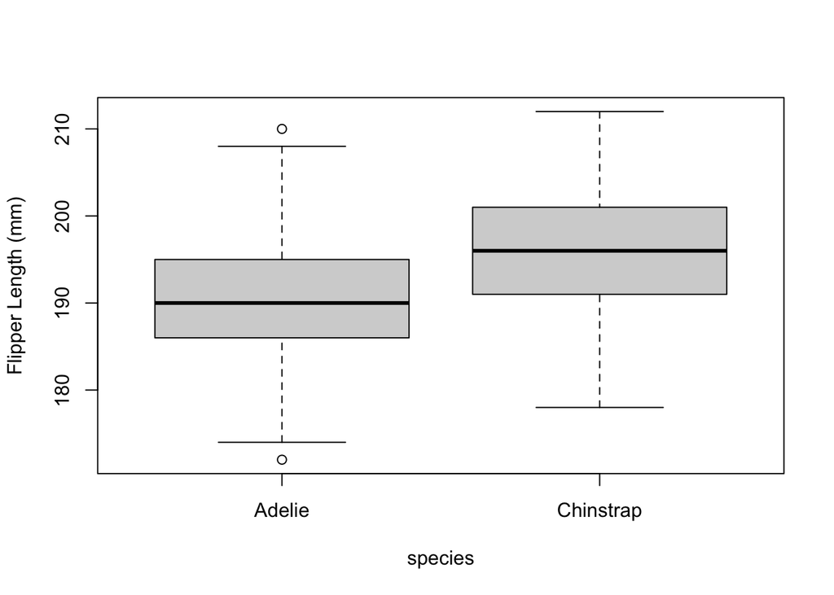

```r
boxplot(
  flipper_length_mm ~ species,
  data = penguin_dat,
  ylab = "Flipper Length (mm)")
```

```r
# Extract the Adelie penguin data
dat_adelie = subset(penguin_dat, species == "Adelie")
dat_chinstrap = subset(penguin_dat, species == "Chinstrap")

t.test(dat_adelie$flipper_length_mm, dat_chinstrap$flipper_length_mm)
```

```
##
##  Welch Two Sample t-test
##
## data:  dat_adelie$flipper_length_mm and dat_chinstrap$flipper_length_mm
## t = -5.7804, df = 119.68, p-value = 6.049e-08
## alternative hypothesis: true difference in means is not equal to 0
## 95 percent confidence interval:
##  -7.880530 -3.859244
## sample estimates:
## mean of x mean of y
##  189.9536  195.8235
```

```r
wilcox.test(dat_adelie$flipper_length_mm, dat_chinstrap$flipper_length_mm)
```

```
##
##  Wilcoxon rank sum test with continuity correction
##
## data:  dat_adelie$flipper_length_mm and dat_chinstrap$flipper_length_mm
## W = 2733.5, p-value = 3.028e-08
## alternative hypothesis: true location shift is not equal to 0
```

```r
shapiro.test(dat_adelie$flipper_length_mm)
```

```
##
##  Shapiro-Wilk normality test
##
## data:  dat_adelie$flipper_length_mm
## W = 0.99339, p-value = 0.72
```

```r
shapiro.test(dat_chinstrap$flipper_length_mm)
```

```
##
##  Shapiro-Wilk normality test
##
## data:  dat_chinstrap$flipper_length_mm
## W = 0.98891, p-value = 0.8106
```

```r
levels(penguin_dat$species)
```

```
## [1] "Adelie"    "Chinstrap"
```

# Assignment Questions

## Question 1

### Create a histogram of the salamander reproduction catastrophic rates. Make sure you include an appropriate title and label for the x-axis.

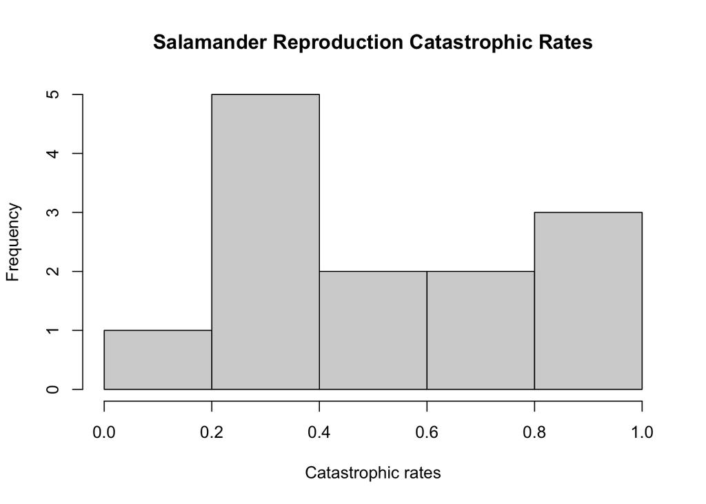

```r
# require(here)
# catrate = read.csv(here("data", "catrate.csv"))
# head(catrate)

hist(catrate$cat.rate, main = "Salamander Reproduction Catastrophic Rates", xlab = "Catastrophic rates")
```

## Question 2

### Conduct a Shapiro-Wilk test of normality of the salamander catastrophic rates. Report the p-value and show the R-code you used to conduct the test.

The p-value is 0.04097.

```r
shapiro.test(catrate$cat.rate)
```

```
##
##  Shapiro-Wilk normality test
##
## data:  catrate$cat.rate
## W = 0.86202, p-value = 0.04097
```

## Question 3

### What is the null hypothesis for the Shapiro test?

The null hypothesis is that the salamander catastrophic rates come from a normally distributed population.

## Question 4

### Based on the Shapiro test results, is there strong evidence that the sample came from a non-normally-distributed population?

Since the p-value is pretty low, I believe there is evidence that the sample came from a non-normally-distributed population.

## Question 5

### Show the code you used to conduct the t-test.

```r
t.test(catrate$cat.rate, mu = 2/7)
```

```
##
##  One Sample t-test
##
## data:  catrate$cat.rate
## t = 2.9595, df = 12, p-value = 0.01193
## alternative hypothesis: true mean is not equal to 0.2857143
## 95 percent confidence interval:
##  0.3526250 0.7261295
## sample estimates:
## mean of x
## 0.5393773
```

## Question 6

### State the null hypothesis of the test, in plain nontechnical English.

The null hypothesis is that the mean of the catastrophe rate is the same as the mean of the pond late-filling rate.

## Question 7

### Is this a one- or two-tailed test?

This is a two-tailed test.

## Question 8

### What is the p-value from your t-test? Interpret the p-value as a false-positive rate using nontechnical English that a non-scientist would understand.

The p-value is 0.01193. This means that the false-positive rate is about 1.2%, so that if we repeated the sampling many times the mean catastrophe rate and mean pond late-filling rates are the same about 1.2% of the time.

## Question 9

### What is the confidence interval for the difference between the null hypothesis and alternative hypothesis means? Did it include zero?

0.3526250 to 0.7261295. This does not include 0.

## Question 10

### Considering the results from your t-test, did you conclude that there was strong evidence to reject the null hypothesis? Make sure you justify your answer using the output of the t-test.

I do think that there is strong evidence to reject the null hypothesis. I think this because the p-value I calculated (0.01193) is quite low, which means that the the null hypothesis is only true 1.2% of the time the sampling is repeated.

## Question 11

### Show the code you used to conduct the test.

```r
wilcox.test(catrate$cat.rate, mu = 2 / 7)
```

```
##
##  Wilcoxon signed rank test with continuity correction
##
## data:  catrate$cat.rate
## V = 85, p-value = 0.006275
## alternative hypothesis: true location is not equal to 0.2857143
```

## Question 12

### Compare the p-value with the p-value you got from the t-test.

The p-value I got from the Wilcoxen test is 0.006275, whereas the p-value I got from the t-test was 0.01193. The Wilcoxen p-value was lower than the t-test p-value.

## Question 13

### Considering the results from your rank sum test, did you conclude that there was strong evidence to reject the null hypothesis? Make sure you justify your answer using the output of the test.

I do think that there is strong evidence to reject the null hypothesis. I think this because the p-value I calculated (0.006275) is quite low, which means that the the null hypothesis is only true 0.6% of the time the sampling is repeated.

## Question 14

### Compare the overall conclusions you could draw from the results of the two tests.

For both of the tests I concluded that there is evidence to reject the null hypothesis. However, because the p-value from the Wilcoxen test was lower than that from the t-test, there is more evidence to reject the Wilcoxen null hypothesis.

## Question 15

### Considering the numerical and graphical data exploration, which test do you think was more appropriate for these data?

Since the t-test is based on the data being normally distributed (or close to), and the salamander data is not normally distributed, the Wilcoxen test seems more appropriate for the data.

## Question 16

### Show the R-code you used to conduct tests of normality for the flipper lengths of Chinstrap and Adelie penguins.

```r
# require(palmerpenguins)
penguin_dat = droplevels(subset(penguins, species != "Gentoo"))
dat_adelie = subset(penguin_dat, species == "Adelie")
dat_chinstrap = subset(penguin_dat, species == "Chinstrap")

shapiro.test(dat_adelie$flipper_length_mm)
```

```
##
##  Shapiro-Wilk normality test
##
## data:  dat_adelie$flipper_length_mm
## W = 0.99339, p-value = 0.72
```

```r
shapiro.test(dat_chinstrap$flipper_length_mm)
```

```
##
##  Shapiro-Wilk normality test
##
## data:  dat_chinstrap$flipper_length_mm
## W = 0.98891, p-value = 0.8106
```

## Question 17

### Interpret the test results. Do you conclude that the flipper lengths are normally-distributed for each species? Make sure your answers make reference to the test output.

Both of the Shapiro-Wilk tests that I conducted for Adelie and Chinstrap penguins had high p-values (0.72 and 0.81, respectively), which lead me towards accepting the null hypothesis that the data is normally distributed. So, I do conclude that the flipper lengths are normally-distributed for each species.

## Question 18

### Create a single figure consisting of histograms of flipper lengths of Adelie and Chinstrap penguins. Save your figure to a file and include it in your report. Your figure needs to have appropriate dimensions such that the two histograms are not vertically stretched.

Submitted to Moodle.

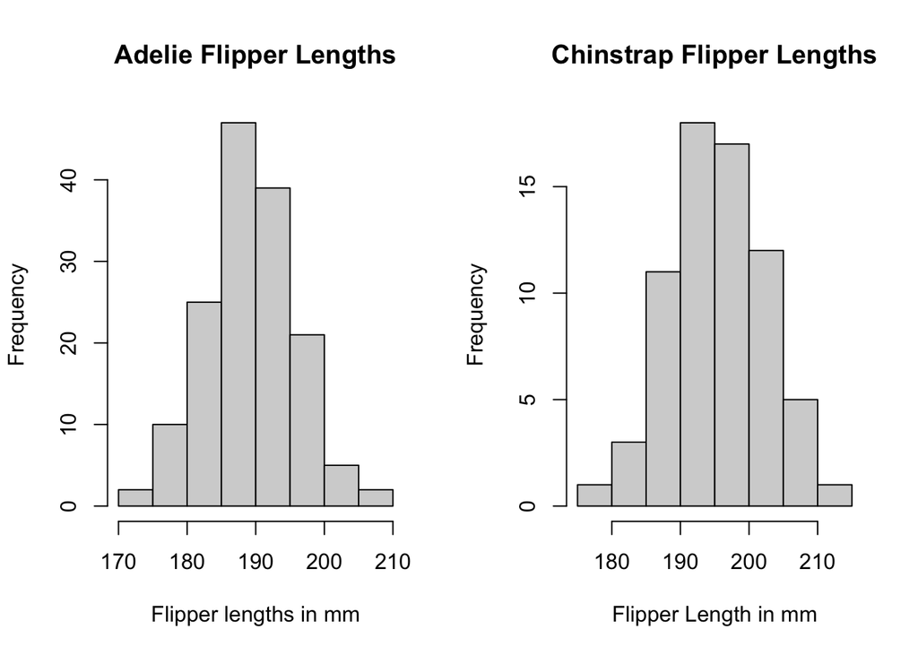

```r
# png(
#   filename = here("using_models_1_hist.png"),
#   width = 1500, height = 800,
#   res = 180, units = "px")

par(mfrow = c(1,2))

hist(dat_adelie$flipper_length_mm,
     main = "Adelie Flipper Lengths",
     xlab = "Flipper lengths in mm")
hist(dat_chinstrap$flipper_length_mm,
     main = "Chinstrap Flipper Lengths",
     xlab = "Flipper Length in mm")
```

## Question 19

### State the alternative hypothesis of the test, in plain nontechnical English. Consider whether you used a one- or two- tailed test.

The alternative hypothesis is that the mean flipper lengths of the Adelie and Chinstrap penguins are different from each other. This is a two-tailed test because we don’t want to know which mean is larger, only that there is a difference between the means.

## Question 20

### Include the code you used to conduct the t-test.

```r
t.test(flipper_length_mm ~ species, data = penguin_dat)
```

```
##
##  Welch Two Sample t-test
##
## data:  flipper_length_mm by species
## t = -5.7804, df = 119.68, p-value = 6.049e-08
## alternative hypothesis: true difference in means between group Adelie and group Chinstrap is not equal to 0
## 95 percent confidence interval:
##  -7.880530 -3.859244
## sample estimates:
##    mean in group Adelie mean in group Chinstrap
##                189.9536                195.8235
```